# Análisis Universidad El Bosque

LN-FESI

5/4/2021

El análisis bioinformático se realizó en dos partes: 1) el preprocesamiento y 2) la identificación y análisis de variantes. Para implementar el flujo de trabajo, se consideró que el enriquecimiento de la región codificante de 127 genes, se realizó mediante el método de captura de híbridos con el kit xGen Pan-Cancer Panel (Integrated DNA Technologies (IDT), Coralville, Iowa, USA) con un target de 800 kb. También la plataforma de secuenciación, Illumina HiSeq 4000.

## Métricas de calidad

A continuación se detallan las calidad de las lecturas crudas de los archivos de secuenciación (fastq) y del alineamiento del archivo binario (bam).

### Métricas Fastq

Se obtuvo la calidad de las secuencias crudas de los archivos .fastq con el programa FastQc (Andrews, 2010), posteriormente con MultiQc (Ewels, 2016) se generó un reporte único de todas las muestras. A continuación se presenta la calidad de las lecturas crudas: en el primer panel por posición en pares de bases (bp) y en el segundo panel la distribución de la calidad por muestra. En ambos casos la calidad fue evaluada con el Phred score.

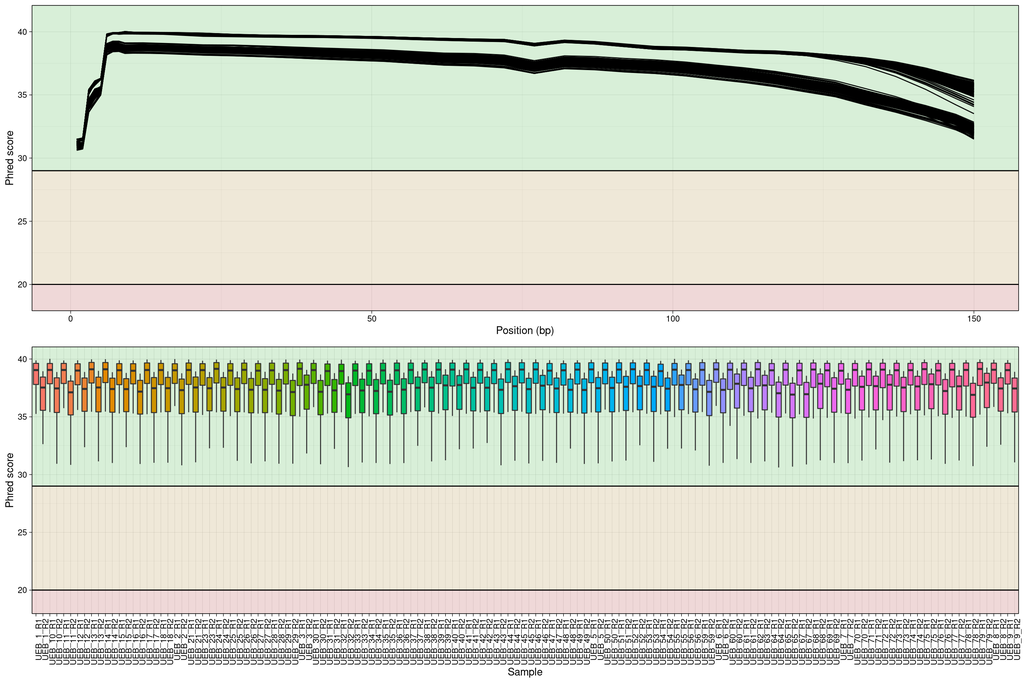

### Métricas de alineamiento

Las secuencias fueron alineadas con bwa-mem (H. Li and durbin 2009), utilizando como referencia el genoma hg 19. Las siguientes herramientas de GATK fueron utilizadas para el resto del preprocesamiento (Van der Auwera 2013): *‘SortSam’* para ordenar, las secuencias alineadas, del primer cromosoma hasta los cromosomas sexuales; *‘SamFortmatConverter’* para convertir las secuencias en archivos binarios; *‘MarkDupliucates’* identificó los duplicados de PCR, que actúan como artefactos en la identificación de variantes; *‘BaseRecalibrator’* y *‘ApplyBQSR’* para recalibrar el score de la calidad de las bases secuenciadas y por último *‘Mutect2’* para el llamado de variantes. Las métricas de alineamiento consisten en la profundidad media (Mean Target Coverage), el porcentaje de lecturas duplicadas (Duplicates (%)) y las lecturas que están fuera del target del kit de captura (Off Target (%)). Especificamos en distintos colores la calidad para cada tipo de tejido.

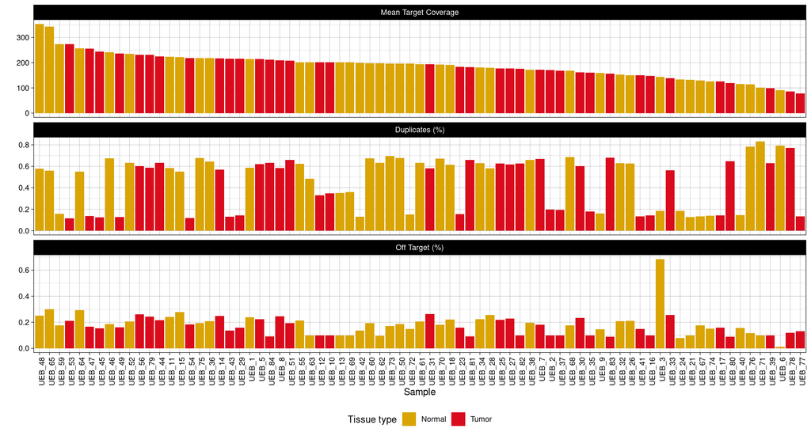

De manera adicional mostramos la cobertura por profundidad de 1 X hasta 100 X y el promedio de la cobertura por profundidad en cada tipo de tejido.

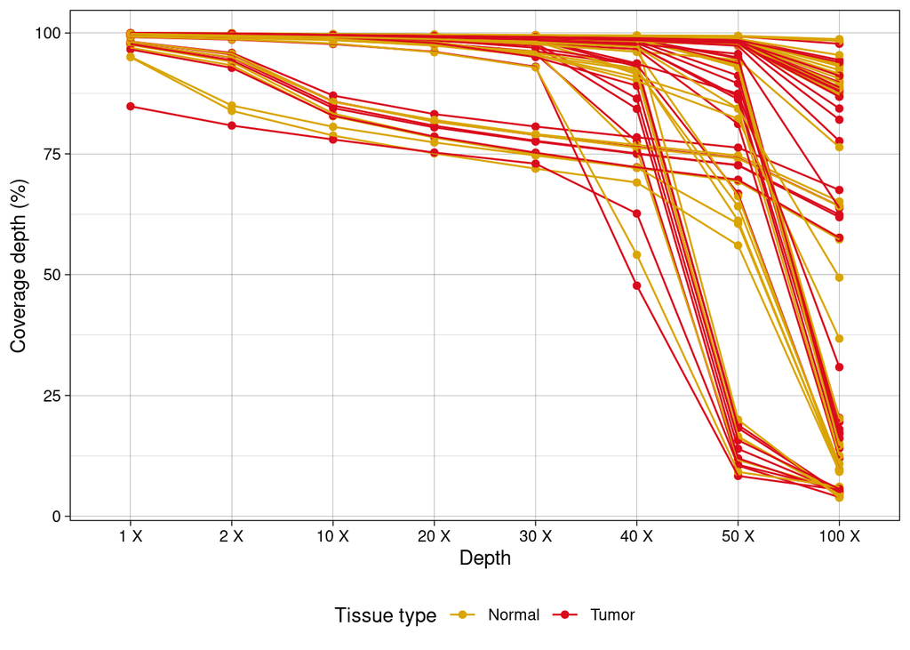

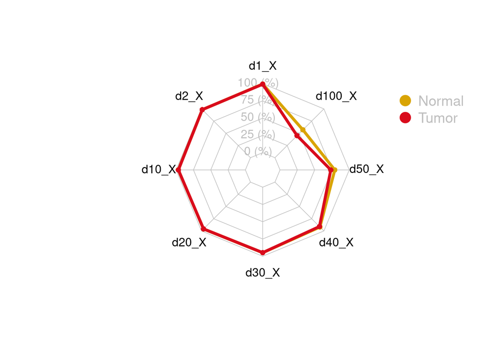

## Análisis de variantes

### Filtrado

Los archivos derivados del llamado de variantes fueron anotados utilizando wAnnovar (http://wannovar.wglab.org/) (Wang, Li, and Hakonarson 2010). Con los archivos resultantes se consolidó un documento único del que se extrajeron las variantes patogénicas y las variantes de significado clínico incierto (VUS). Para la identificación de dichas variantes se considera una fracción alélica (AF) >0.05 y que la lectura mutada estuviera presente por lo menos dos veces en cada sentido de las lecturas. Para filtrar y clasificar las variantes se utilizaron los siguintes criterios: *a)* localizadas en la región exónica, 5’UTR, 3’UTR, ncRNA o de splicing, *b)* Clasificadas patogénicas por ClinVar (Laundrum 2018), *c)* frecuencia < 0.001 gnomAD (https://gnomad.broadinstitute.org/) (Karczewski et al. 2019), *d)* exlcuimos SNPs de dbSNP (https://www.ncbi.nlm.nih.gov/snp/) y *e)* predicción de alelo deletéreo en por los menos dos de los tres predictores: SIFT, PolyPhen-1 y Mutational Taster en las muestras que no fueron catalogadas como patogénicas por ClinVar (Adzhubei et al. 2010; Ng and Henikoff 2003; Schwarz et al. 2014). A continuación se observa el número total de variantes detectadas en cada paso del filtrado.

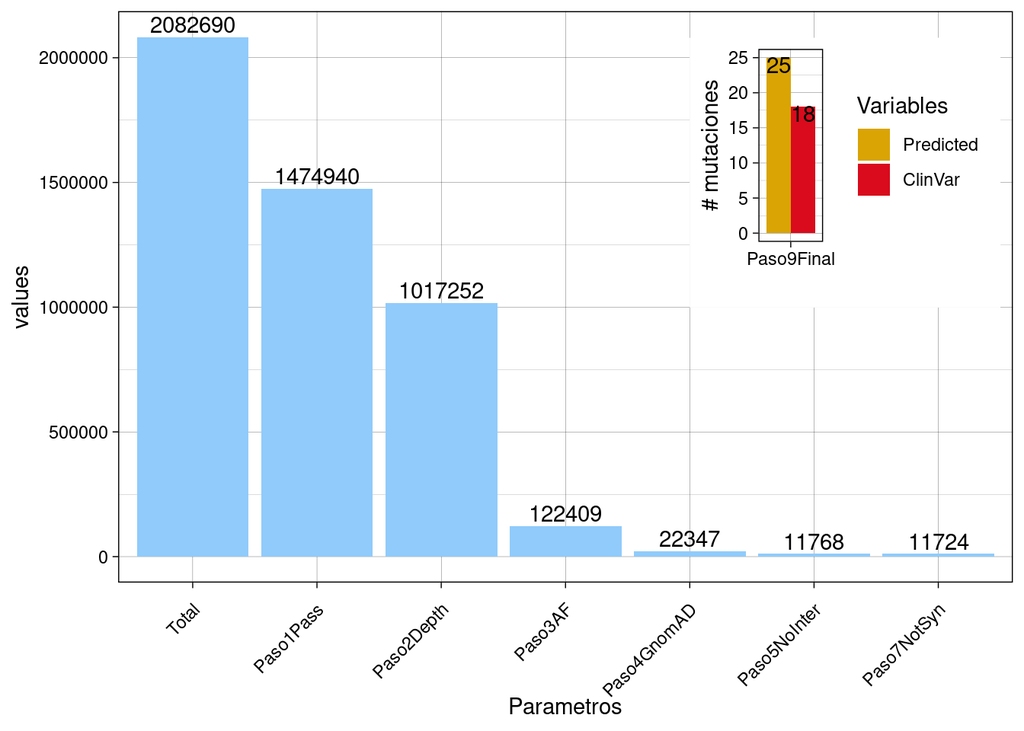

### TMB

La carga mutacional tumoral (TMB) se definió como el número de mutaciones somáticas, de sustitución de bases y deleciones por kilobase en el genoma examinado. Se obtuvo un promedio de 0.75 mutaciones/Kb.

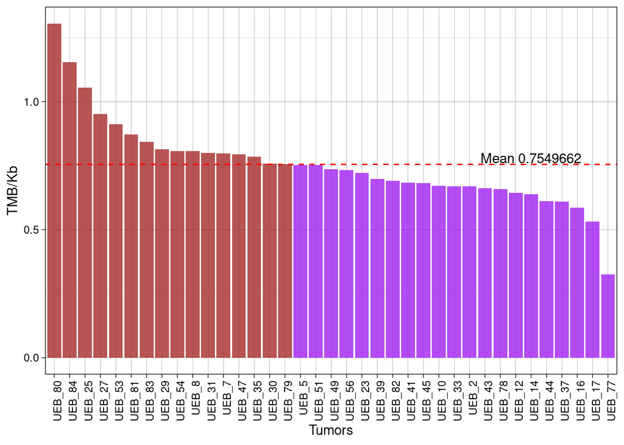

### Frecuencia de genes

A continuación se presenta de las variantes filtradas la frecuencia de los genes y la distribución de las mutaciones conductoras detectadas. En ambas se especifica los genes supresores tumorales (LoF (Loss of Function), oncogenes (Act) y de clasificación ambigua (ambiguous).

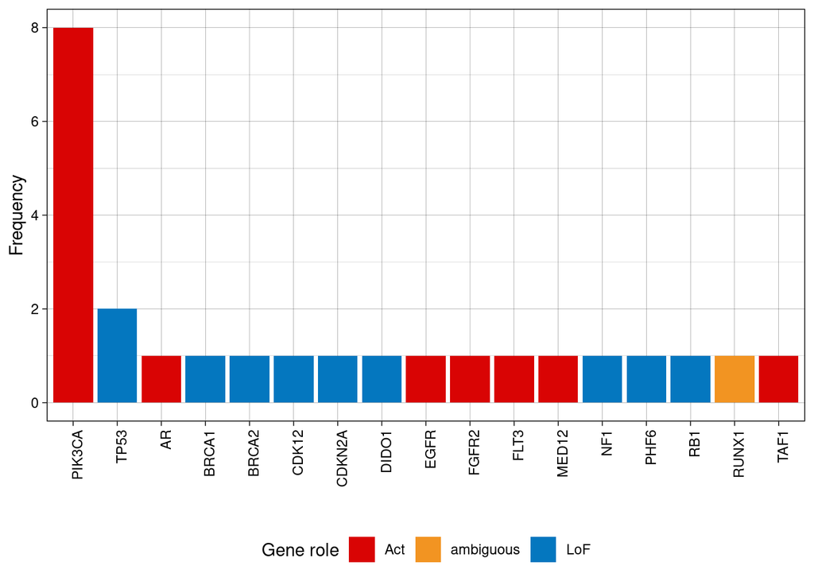

### Distribución alélica

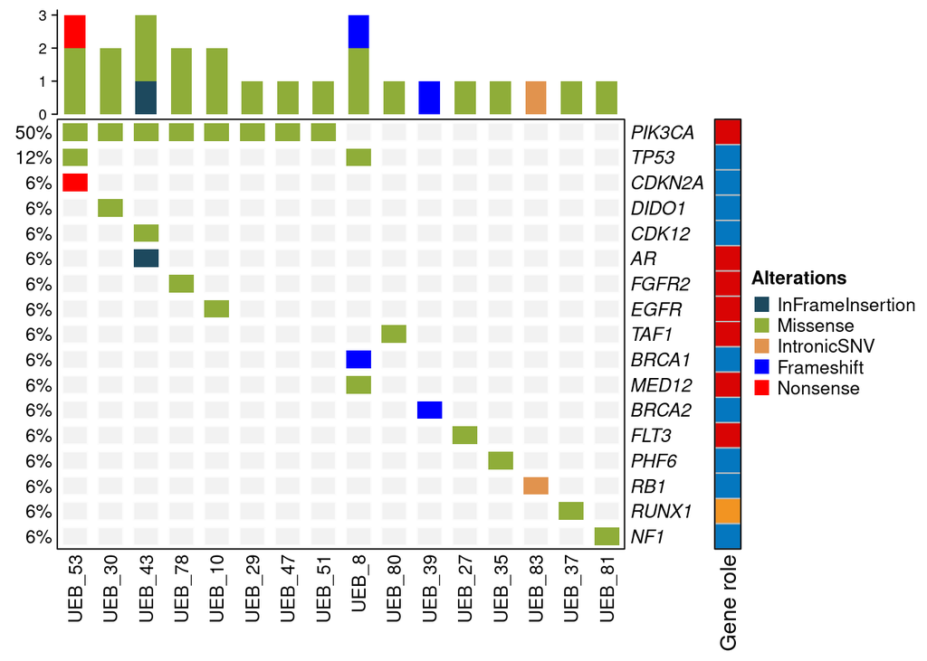